# Portfolio Project: Online Retail Exploratory Data Analysis with Python

- Introduction
- Data
- Methodology
- Analysis
- Results and Discussion
- Conclusion

## 1.1. Background

In this project, we worked with transactional data from an online retail store. The dataset contains information about customer purchases, including product details, quantities, prices, and timestamps. Ultimately, this project aims to provide actionable insights that can drive strategic business decisions and enhance the store's overall performance in the competitive online retail market.

# 1.2. Problem

Explore and analyze the dataset to gain insights into the store's sales trends, customer behavior, and popular products, helping interpret real-world data to help make a key business decision.

# 1.3 Interest

This report is targeted to anyone interested in the online retail store data analysis.

# Data

The dataset contains transactional data of an online retail store from 2010 to 2011. The dataset is available as a .xlsx file named Online Retail.xlsx.

The dataset contains the following columns:

- InvoiceNo: Invoice number of the transaction
- StockCode: Unique code of the product
- Description: Description of the product
- Quantity: Quantity of the product in the transaction
- InvoiceDate: Date and time of the transaction
- UnitPrice: Unit price of the product
- CustomerID: Unique identifier of the customer
- Country: Country where the transaction occurred

# Methodology

We conducted exploratory data analysis such as boxplots, bar graphs to identify patterns, outliers, and correlations in the data.This allowed us to make data-driven decisions and recommendations to optimize the store's operations and improve customer satisfaction.

We performed Data Cleaning to prepare data for analysis. It is a process of preparing data to meet the quality criteria such as validity, uniformity, accuracy, consistency, and completeness. Data cleansing removes unwanted, duplicate, and incorrect data from datasets, thus helping the analyst to develop accurate insight: https://www.dataversity.net/data-cleansing-why-its-important/.

Through visualizations and statistical analysis, we uncovered key trends, such as the busiest sales months, best-selling products, and the store's most valuable customers.

# 4.1 Basic Explanatory Analysis

```python
df_data_info
```

|  | Count | Type | PercOfTotalRows |
| --- | --- | --- | --- |
| 0 | 536641 | TotalRows | 100.000000 |
| 1 | 5268 | Dups | 0.981662 |
| 2 | 1454 | NullDescription | 0.270945 |
| 3 | 135037 | NullCustID | 25.163377 |
| 4 | 9727 | QuantOrUnitPriceNegative | 1.812571 |
| 5 | 9 | UnitPriceOutlier | 0.001677 |
| 6 | 3 | QuantityOutlier | 0.000559 |
| 7 | 581 | 0Sales | 0.108266 |
| 8 | 442 | UnspecifiedCountry | 0.082364 |

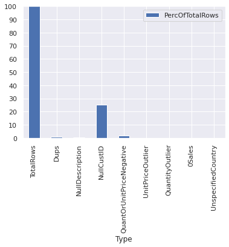

```python
ax=df_data_info.plot(x='Type', y='PercOfTotalRows', kind='bar')
#ax.set_yscale('log')
ax.set_ylim(0, 100)  # Set the y-axis limits
ax.set_yticks(range(0, 101, 10))
plt.show()
```

**Outliers**

```python
# 9 UnitPrice Outliers (fee, postages, manual, Adjust bad debt!!), not sure what Manual and Adjust bad debt do mean.
df_cleaned_final[df_cleaned_final['UnitPrice'] > 3000]
```

|  | Description | Quantity | InvoiceDate | UnitPrice | Country |
| --- | --- | --- | --- | --- | --- |
| 15017 | AMAZON FEE | 1 | 2010-12-07 15:08:00 | 13541.33 | United Kingdom |
| 173382 | POSTAGE | 1 | 2011-05-03 13:46:00 | 8142.75 | United Kingdom |
| 268028 | Manual | 1 | 2011-07-18 12:30:00 | 4287.63 | United Kingdom |
| 297723 | DOTCOM POSTAGE | 1 | 2011-08-11 10:14:00 | 4505.17 | United Kingdom |
| 299982 | Adjust bad debt | 1 | 2011-08-12 14:50:00 | 11062.06 | United Kingdom |
| 374542 | Manual | 1 | 2011-10-03 16:44:00 | 3155.95 | United Kingdom |
| 406406 | Manual | 1 | 2011-10-19 11:18:00 | 3949.32 | Singapore |
| 422351 | Manual | 1 | 2011-10-27 14:13:00 | 4161.06 | France |
| 422376 | Manual | 1 | 2011-10-27 14:20:00 | 4161.06 | France |

```python
# 3 Quantity outlier
# Should not discard MEDIUM CERAMIC TOP STORAGE JAR and PAPER CRAFT , LITTLE BIRDIE outliers in forcasting future sales in United Kingdom.
# These seems the  most sellable items!
df_cleaned_final[df_cleaned_final['Quantity'] > 10000]
```

|  | Description | Quantity | InvoiceDate | UnitPrice | Country |
| --- | --- | --- | --- | --- | --- |
| 61619 | MEDIUM CERAMIC TOP STORAGE JAR | 74215 | 2011-01-18 10:01:00 | 1.04 | United Kingdom |
| 502122 | ASSTD DESIGN 3D PAPER STICKERS | 12540 | 2011-11-25 15:57:00 | 0.00 | United Kingdom |
| 540421 | PAPER CRAFT , LITTLE BIRDIE | 80995 | 2011-12-09 09:15:00 | 2.08 | United Kingdom |

**Anomalies**

- 5268 duplicate rows in input data can skew the results and compromise the accuracy of the analysis performed on the data. They can impact inefficiencies, increased storage costs, potential inconsistencies in data integrity, incorrect statistics. Duplicate rows indicate data management problems and lack of methods to detect redundant observations. https://dataladder.com/why-data-duplicates-exist-how-to-get-rid-of-them/ https://www.lexjansen.com/pharmasug/1998/CODERS/CHENG.PDF

**The following clearly impacts data consistency, indicates data management problems and lack of methods to identify missing values for crucial fields:**

- 1454 rows have missing Description
- about 25% of all rows have missing CustID (unique identifier of the customer)
- 9727 rows where ether Quantity or UnitPrice are negative
- 581 rows with zero Sales (Quantity * UnitPrice) because of 0 UnitPrice
- 442 rows do not have Country where the transaction occurred.

**The basic statistics of the cleaned dataset**

```python
df_cleaned[['Quantity','UnitPrice','Sales']].describe()
```

|  | Quantity | UnitPrice | Sales |
| --- | --- | --- | --- |
| count | 524867.000000 | 524867.000000 | 524867.000000 |
| mean | 10.321093 | 3.814114 | 19.699260 |
| std | 37.914470 | 20.158813 | 86.717175 |
| min | 1.000000 | 0.001000 | 0.001000 |
| 25% | 1.000000 | 1.250000 | 3.900000 |
| 50% | 4.000000 | 2.080000 | 9.920000 |
| 75% | 11.000000 | 4.130000 | 17.700000 |
| max | 4800.000000 | 2653.950000 | 38970.000000 |

# Results

- The most frequent products are WHITE HANGING HEART T-LIGHT HOLDER and JUMBO BAG RED RETROSPOT

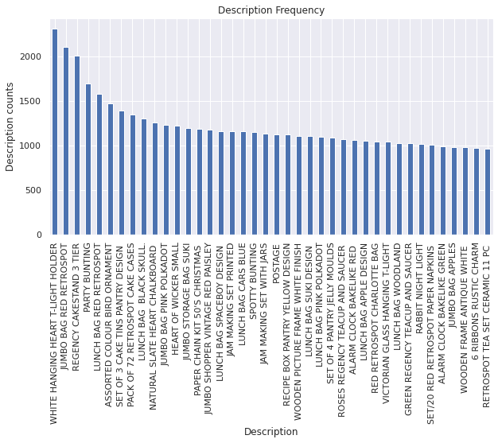

```python
df_cleaned_final.Description.value_counts().nlargest(40).plot(kind='bar', figsize=(10,5))
plt.title("Description Frequency")
plt.ylabel('Description counts')
plt.xlabel('Description')
```

- The most frequent quantity sizes are 1 and 2

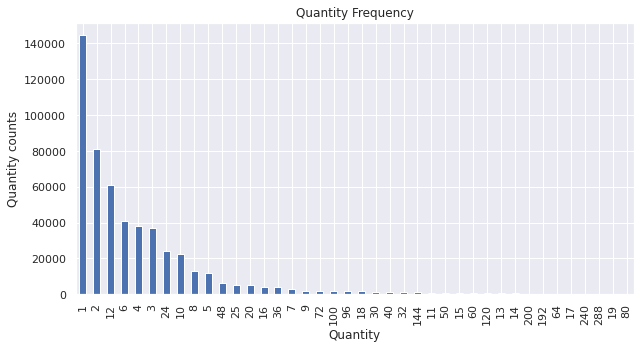

```python
df_cleaned_final.Quantity.value_counts().nlargest(40).plot(kind='bar', figsize=(10,5))
plt.title("Quantity Frequency")
plt.ylabel('Quantity counts')
plt.xlabel('Quantity')
```

- Top 20 sales where Sales = Quantity * UnitPrice

DOTCOM POSTAGE is the top sale.

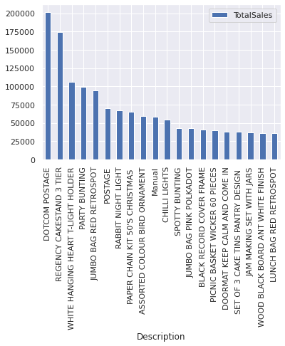

```python
df_sales.head(20).plot(x='Description', y='TotalSales', kind='bar')
plt.show()
```

- Least 20 sales where Sales = Quantity * UnitPrice

PADS TO MATCH ALL CUSHIONS has the smallest sales

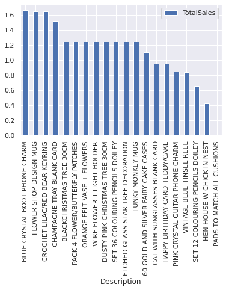

```python
df_sales[df_sales['TotalSales'] > 0].tail(20).plot(x='Description', y='TotalSales', kind='bar')
plt.show()
```

- moderate positive correlation of 0.495794 between Quantity and Sales is expected (more quantity sold larger sales)
- weak positive correlation of 0.259481 between UnitPrice and Sales indicates larger UnitPrice would generate larger Sales
- very weak negative correlation of -0.025731, almost no correlation, between Quantity and UnitPrice.

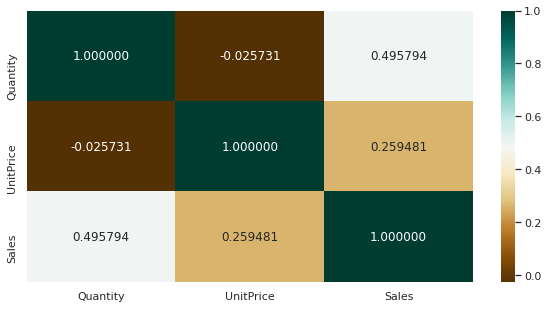

```python
plt.figure(figsize=(10,5))
c= df_cleaned.corr()
sns.heatmap(c,cmap="BrBG",annot=True, fmt=".6f")
```

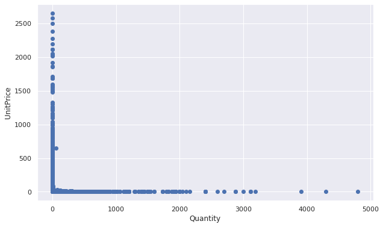

```python
fig, ax = plt.subplots(figsize=(10,6))
ax.scatter(df_cleaned['Quantity'], df_cleaned['UnitPrice'])
ax.set_xlabel('Quantity')
ax.set_ylabel('UnitPrice')
plt.show()
```

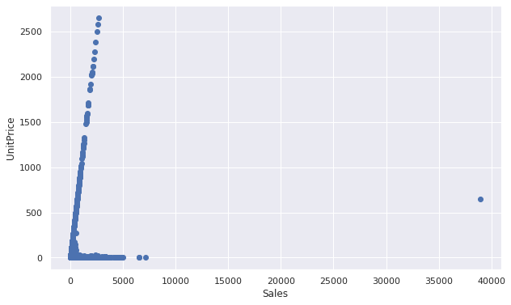

```python
fig, ax = plt.subplots(figsize=(10,6))
ax.scatter(df_cleaned['Sales'], df_cleaned['UnitPrice'])
ax.set_xlabel('Sales')
ax.set_ylabel('UnitPrice')
plt.show()
```

```python
# the above Sales outlier is for PICNIC BASKET WICKER 60 PIECES product
df_cleaned[df_cleaned['Sales'] > 35000]
```

|  | Description | Quantity | InvoiceDate | UnitPrice | Country | Sales | year_quarter | day_of_week | year_month |
| --- | --- | --- | --- | --- | --- | --- | --- | --- | --- |
| 222680 | PICNIC BASKET WICKER 60 PIECES | 60 | 2011-06-10 15:28:00 | 649.5 | United Kingdom | 38970.0 | 2011Q2 | Friday | 2011-06 |

- About 84% Total Sales in United Kingdom, 16% in all other countries
- The smallest Total Sales in Saudi Arabia

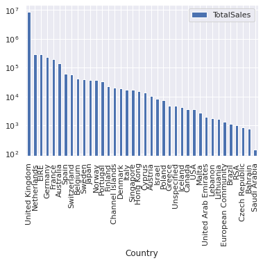

```python
ax=df_sales_by_country.plot(x='Country', y='TotalSales', kind='bar')
ax.set_yscale('log')
plt.show()
```

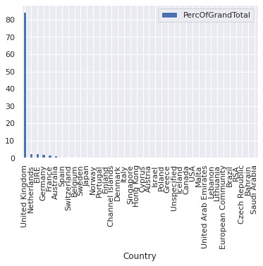

```python
ax=df_sales_by_country.plot(x='Country', y='PercOfGrandTotal', kind='bar')
plt.show()
```

- Notice above Unspecified country!

```python
df_country_unspec = df_cleaned[df_cleaned['Country'] == 'Unspecified']
print('Shape of Unspecified country: ',df_country_unspec.shape)
df_country_unspec.head(10)
```

```
Shape of Unspecified country:  (442, 9)
```

|  | Description | Quantity | InvoiceDate | UnitPrice | Country | Sales | year_quarter | day_of_week | year_month |
| --- | --- | --- | --- | --- | --- | --- | --- | --- | --- |
| 152712 | DOORMAT RED RETROSPOT | 2 | 2011-04-11 13:29:00 | 7.95 | Unspecified | 15.9 | 2011Q2 | Monday | 2011-04 |
| 152713 | DOORMAT WELCOME SUNRISE | 2 | 2011-04-11 13:29:00 | 7.95 | Unspecified | 15.9 | 2011Q2 | Monday | 2011-04 |
| 152714 | DOORMAT MULTICOLOUR STRIPE | 2 | 2011-04-11 13:29:00 | 7.95 | Unspecified | 15.9 | 2011Q2 | Monday | 2011-04 |
| 152715 | PACK OF 72 SKULL CAKE CASES | 24 | 2011-04-11 13:29:00 | 0.55 | Unspecified | 13.2 | 2011Q2 | Monday | 2011-04 |
| 152716 | PACK OF 60 PINK PAISLEY CAKE CASES | 24 | 2011-04-11 13:29:00 | 0.55 | Unspecified | 13.2 | 2011Q2 | Monday | 2011-04 |
| 152717 | PACK OF 60 MUSHROOM CAKE CASES | 24 | 2011-04-11 13:29:00 | 0.55 | Unspecified | 13.2 | 2011Q2 | Monday | 2011-04 |
| 152718 | PACK OF 72 RETROSPOT CAKE CASES | 24 | 2011-04-11 13:29:00 | 0.55 | Unspecified | 13.2 | 2011Q2 | Monday | 2011-04 |
| 152719 | 72 SWEETHEART FAIRY CAKE CASES | 24 | 2011-04-11 13:29:00 | 0.55 | Unspecified | 13.2 | 2011Q2 | Monday | 2011-04 |
| 152720 | 60 TEATIME FAIRY CAKE CASES | 24 | 2011-04-11 13:29:00 | 0.55 | Unspecified | 13.2 | 2011Q2 | Monday | 2011-04 |
| 152721 | SET OF 36 PAISLEY FLOWER DOILIES | 12 | 2011-04-11 13:29:00 | 1.45 | Unspecified | 17.4 | 2011Q2 | Monday | 2011-04 |

- Top 3 selling products based on Sales for each country

```python
df_sales_by_country_top_product = df_cleaned[['Country','Description','Sales']].groupby(['Country','Description']).sum()
df_sales_by_country_top_product.rename(columns={'Sales': 'TotalProductSales'}, inplace=True)
df_sales_by_country_top_product.sort_values(by=['Country','TotalProductSales'], ascending=[True, False], inplace=True)
df_sales_by_country_top_product.reset_index(inplace=True)
df_sales_by_country_top_product['Rank']=df_sales_by_country_top_product.groupby('Country').cumcount() + 1

# For each country, limit to top 3 purchased products
df_sales_by_country_3top_product = df_sales_by_country_top_product[df_sales_by_country_top_product['Rank'] <=3]
df_sales_by_country_3top_product.reset_index(inplace=True)
print('Shape of df_sales_by_country_3top_product: ',df_sales_by_country_3top_product.shape)

pd.set_option('max_row', None)
df_sales_by_country_3top_product
```

```
Shape of df_sales_by_country_3top_product:  (114, 5)
```

|  | index | Country | Description | TotalProductSales | Rank |
| --- | --- | --- | --- | --- | --- |
| 0 | 0 | Australia | RABBIT NIGHT LIGHT | 3375.84 | 1 |
| 1 | 1 | Australia | SET OF 6 SPICE TINS PANTRY DESIGN | 2082.00 | 2 |
| 2 | 2 | Australia | RED TOADSTOOL LED NIGHT LIGHT | 1987.20 | 3 |
| 3 | 608 | Austria | POSTAGE | 1456.00 | 1 |
| 4 | 609 | Austria | PACK OF 6 PANNETONE GIFT BOXES | 302.40 | 2 |
| 5 | 610 | Austria | PACK OF 6 SWEETIE GIFT BOXES | 302.40 | 3 |
| 6 | 914 | Bahrain | OCEAN SCENT CANDLE IN JEWELLED BOX | 231.24 | 1 |
| 7 | 915 | Bahrain | ICE CREAM SUNDAE LIP GLOSS | 120.00 | 2 |
| 8 | 916 | Bahrain | DOUGHNUT LIP GLOSS | 75.00 | 3 |
| 9 | 930 | Belgium | POSTAGE | 4269.00 | 1 |
| 10 | 931 | Belgium | ROUND SNACK BOXES SET OF4 WOODLAND | 1181.40 | 2 |
| 11 | 932 | Belgium | DOLLY GIRL LUNCH BOX | 643.80 | 3 |
| 12 | 1714 | Brazil | REGENCY CAKESTAND 3 TIER | 175.20 | 1 |
| 13 | 1715 | Brazil | SET OF 6 SPICE TINS PANTRY DESIGN | 82.80 | 2 |
| 14 | 1716 | Brazil | SET/3 RED GINGHAM ROSE STORAGE BOX | 81.36 | 3 |
| 15 | 1746 | Canada | POSTAGE | 550.94 | 1 |
| 16 | 1747 | Canada | RETRO COFFEE MUGS ASSORTED | 534.24 | 2 |
| 17 | 1748 | Canada | LUNCH BAG BLACK SKULL. | 82.50 | 3 |
| 18 | 1893 | Channel Islands | REGENCY CAKESTAND 3 TIER | 517.80 | 1 |
| 19 | 1894 | Channel Islands | JUMBO BAG RED RETROSPOT | 460.70 | 2 |
| 20 | 1895 | Channel Islands | SET OF 3 CAKE TINS PANTRY DESIGN | 408.00 | 3 |
| 21 | 2329 | Cyprus | RUSTIC SEVENTEEN DRAWER SIDEBOARD | 580.00 | 1 |
| 22 | 2330 | Cyprus | EDWARDIAN PARASOL NATURAL | 392.70 | 2 |
| 23 | 2331 | Cyprus | WHITE HANGING HEART T-LIGHT HOLDER | 386.40 | 3 |
| 24 | 2827 | Czech Republic | ROUND SNACK BOXES SET OF4 WOODLAND | 70.80 | 1 |
| 25 | 2828 | Czech Republic | ROTATING SILVER ANGELS T-LIGHT HLDR | 61.20 | 2 |
| 26 | 2829 | Czech Republic | JIGSAW TREE WITH BIRDHOUSE | 52.20 | 3 |
| 27 | 2852 | Denmark | POSTAGE | 744.00 | 1 |
| 28 | 2853 | Denmark | RED KITCHEN SCALES | 734.40 | 2 |
| 29 | 2854 | Denmark | IVORY KITCHEN SCALES | 696.15 | 3 |

[output cut: 84 more lines]

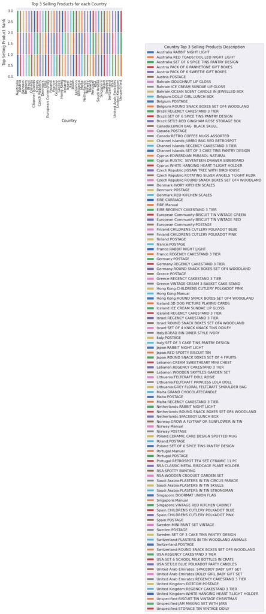

```python
# Count values for each combination of Country and Description
count_df_sales_by_country_3top_product=df_sales_by_country_3top_product.groupby(['Country', 'Description']).size().reset_index(name='Count')
count_df_sales_by_country_3top_product['Country-Description']=count_df_sales_by_country_3top_product['Country']+':'+count_df_sales_by_country_3top_product['Description']

# Pivot the DataFrame for easier plotting
pivot_df_sales_by_country_3top_product = count_df_sales_by_country_3top_product.pivot(index='Country', columns='Country-Description', values='Count')
pivot_df_sales_by_country_3top_product

# Plotting the graph
pivot_df_sales_by_country_3top_product.plot(kind='bar', stacked=True)
plt.xlabel('Country')
plt.ylabel('Top Selling Product Rank')
plt.title('Top 3 Selling Products for each Country')
plt.legend(title='Country-Top 3 Selling Products Description',bbox_to_anchor=(1.2, 0.5))
plt.show()
```

- Top 3 selling products based on quantity for each Country

```python
df_q_by_country_top_product = df_cleaned[['Country','Description','Quantity']].groupby(['Country','Description']).sum()
df_q_by_country_top_product.rename(columns={'Quantity': 'TotalQuantity'}, inplace=True)
df_q_by_country_top_product.sort_values(by=['Country','TotalQuantity'], ascending=[True, False], inplace=True)
df_q_by_country_top_product.reset_index(inplace=True)
df_q_by_country_top_product['Rank']=df_q_by_country_top_product.groupby('Country').cumcount() + 1

# For each country, limit to top 3 purchased products
df_q_by_country_3top_product = df_q_by_country_top_product[df_q_by_country_top_product['Rank'] <=3]
df_q_by_country_3top_product.reset_index(inplace=True)
print('Shape of df_q_by_country_3top_product: ',df_q_by_country_3top_product.shape)

pd.set_option('max_row', None)
df_q_by_country_3top_product
```

```
Shape of df_q_by_country_3top_product:  (114, 5)
```

|  | index | Country | Description | TotalQuantity | Rank |
| --- | --- | --- | --- | --- | --- |
| 0 | 0 | Australia | MINI PAINT SET VINTAGE | 2952 | 1 |
| 1 | 1 | Australia | RABBIT NIGHT LIGHT | 1884 | 2 |
| 2 | 2 | Australia | RED HARMONICA IN BOX | 1704 | 3 |
| 3 | 608 | Austria | SET 12 KIDS COLOUR CHALK STICKS | 288 | 1 |
| 4 | 609 | Austria | MINI JIGSAW PURDEY | 240 | 2 |
| 5 | 610 | Austria | PACK OF 6 PANNETONE GIFT BOXES | 144 | 3 |
| 6 | 914 | Bahrain | ICE CREAM SUNDAE LIP GLOSS | 96 | 1 |
| 7 | 915 | Bahrain | DOUGHNUT LIP GLOSS | 60 | 2 |
| 8 | 916 | Bahrain | OCEAN SCENT CANDLE IN JEWELLED BOX | 60 | 3 |
| 9 | 930 | Belgium | PACK OF 72 RETROSPOT CAKE CASES | 480 | 1 |
| 10 | 931 | Belgium | ROUND SNACK BOXES SET OF4 WOODLAND | 420 | 2 |
| 11 | 932 | Belgium | PACK OF 60 SPACEBOY CAKE CASES | 384 | 3 |
| 12 | 1714 | Brazil | DOLLY GIRL LUNCH BOX | 24 | 1 |
| 13 | 1715 | Brazil | GREEN REGENCY TEACUP AND SAUCER | 24 | 2 |
| 14 | 1716 | Brazil | PINK REGENCY TEACUP AND SAUCER | 24 | 3 |
| 15 | 1746 | Canada | RETRO COFFEE MUGS ASSORTED | 504 | 1 |
| 16 | 1747 | Canada | WORLD WAR 2 GLIDERS ASSTD DESIGNS | 288 | 2 |
| 17 | 1748 | Canada | COLOURING PENCILS BROWN TUBE | 60 | 3 |
| 18 | 1893 | Channel Islands | RAIN PONCHO | 407 | 1 |
| 19 | 1894 | Channel Islands | JUMBO BAG RED RETROSPOT | 250 | 2 |
| 20 | 1895 | Channel Islands | JUMBO BAG BAROQUE BLACK WHITE | 220 | 3 |
| 21 | 2329 | Cyprus | HEART DECORATION PAINTED ZINC | 384 | 1 |
| 22 | 2330 | Cyprus | BOYS ALPHABET IRON ON PATCHES | 288 | 2 |
| 23 | 2331 | Cyprus | GIRLS ALPHABET IRON ON PATCHES | 288 | 3 |
| 24 | 2827 | Czech Republic | WOODEN STAR CHRISTMAS SCANDINAVIAN | 72 | 1 |
| 25 | 2828 | Czech Republic | WOODEN TREE CHRISTMAS SCANDINAVIAN | 72 | 2 |
| 26 | 2829 | Czech Republic | CHRISTMAS TABLE SILVER CANDLE SPIKE | 48 | 3 |
| 27 | 2852 | Denmark | RED HARMONICA IN BOX | 288 | 1 |
| 28 | 2853 | Denmark | SET OF 6 TEA TIME BAKING CASES | 280 | 2 |
| 29 | 2854 | Denmark | GUMBALL COAT RACK | 270 | 3 |

[output cut: 84 more lines]

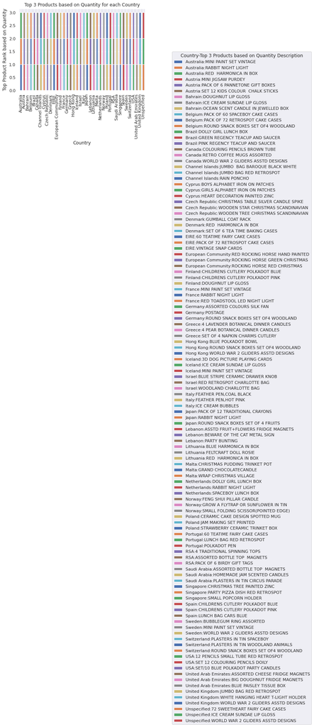

```python
# Count values for each combination of Country and Description
count_df_q_by_country_3top_product=df_q_by_country_3top_product.groupby(['Country', 'Description']).size().reset_index(name='Count')
count_df_q_by_country_3top_product['Country-Description']=count_df_q_by_country_3top_product['Country']+':'+count_df_q_by_country_3top_product['Description']

# Pivot the DataFrame for easier plotting
pivot_df_q_by_country_3top_product = count_df_q_by_country_3top_product.pivot(index='Country', columns='Country-Description', values='Count')
pivot_df_q_by_country_3top_product

# Plotting the graph
pivot_df_q_by_country_3top_product.plot(kind='bar', stacked=True)
plt.xlabel('Country')
plt.ylabel('Top Product Rank based on Quantity')
plt.title('Top 3 Products based on Quantity for each Country')
plt.legend(title='Country-Top 3 Products based on Quantity Description',bbox_to_anchor=(1.2, 0.5))
plt.show()
```

- Total Quantity sold in each Country

```python
df_q_by_country = df_cleaned[['Country','Quantity']].groupby('Country').sum()
df_q_by_country.rename(columns={'Quantity': 'TotalQuantity'}, inplace=True)
df_q_by_country.sort_values(by='TotalQuantity', ascending=False, inplace=True)
df_q_by_country.reset_index(inplace=True)
df_q_by_country.head(40)
```

|  | Country | TotalQuantity |
| --- | --- | --- |
| 0 | United Kingdom | 4491690 |
| 1 | Netherlands | 200361 |
| 2 | EIRE | 147007 |
| 3 | Germany | 119154 |
| 4 | France | 112058 |
| 5 | Australia | 83891 |
| 6 | Sweden | 36078 |
| 7 | Switzerland | 30617 |
| 8 | Spain | 27933 |
| 9 | Japan | 26016 |
| 10 | Belgium | 23237 |
| 11 | Norway | 19336 |
| 12 | Portugal | 16231 |
| 13 | Finland | 10704 |
| 14 | Channel Islands | 9485 |
| 15 | Denmark | 8235 |
| 16 | Italy | 8112 |
| 17 | Cyprus | 6340 |
| 18 | Singapore | 5240 |
| 19 | Austria | 4881 |
| 20 | Hong Kong | 4713 |
| 21 | Israel | 4406 |
| 22 | Poland | 3684 |
| 23 | Unspecified | 3295 |
| 24 | Canada | 2763 |
| 25 | USA | 2458 |
| 26 | Iceland | 2458 |
| 27 | Greece | 1557 |
| 28 | United Arab Emirates | 982 |
| 29 | Malta | 970 |
| 30 | Czech Republic | 671 |
| 31 | Lithuania | 652 |
| 32 | European Community | 499 |
| 33 | Lebanon | 386 |
| 34 | Brazil | 356 |
| 35 | RSA | 351 |
| 36 | Bahrain | 314 |
| 37 | Saudi Arabia | 80 |

- about 83% Total Quantity sold in United Kingdom, 17% in all other countries and this agrees with 84% and 16% based on Sales

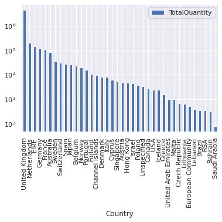

```python
# The largest Total Quantity sold in United Kingdom
# The smallest Total Quantity sold in Saudi Arabia
ax=df_q_by_country.plot(x='Country', y='TotalQuantity', kind='bar')
ax.set_yscale('log')
plt.show()
```

```python
df_q_by_country['GrandTotal'] = df_q_by_country['TotalQuantity'].sum()
df_q_by_country['PercOfGrandTotal']=100*df_q_by_country['TotalQuantity']/df_q_by_country['GrandTotal']
df_q_by_country.head(10)
```

|  | Country | TotalQuantity | GrandTotal | PercOfGrandTotal |
| --- | --- | --- | --- | --- |
| 0 | United Kingdom | 4491690 | 5417201 | 82.915328 |
| 1 | Netherlands | 200361 | 5417201 | 3.698607 |
| 2 | EIRE | 147007 | 5417201 | 2.713708 |
| 3 | Germany | 119154 | 5417201 | 2.199549 |
| 4 | France | 112058 | 5417201 | 2.068559 |
| 5 | Australia | 83891 | 5417201 | 1.548604 |
| 6 | Sweden | 36078 | 5417201 | 0.665990 |
| 7 | Switzerland | 30617 | 5417201 | 0.565181 |
| 8 | Spain | 27933 | 5417201 | 0.515635 |
| 9 | Japan | 26016 | 5417201 | 0.480248 |

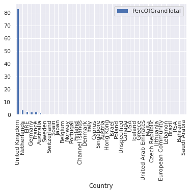

```python
ax=df_q_by_country.plot(x='Country', y='PercOfGrandTotal', kind='bar')
plt.show()
```

- Total Sales by Country and Quarter

```python
df_sales_by_country_q_pivot = df_sales_by_country_q.pivot(index='Country', columns='year_quarter', values='TotalQuarterSales')
df_sales_by_country_q_pivot['TotalSales']=df_sales_by_country_q_pivot['2010Q4'].fillna(0)+df_sales_by_country_q_pivot['2011Q1'].fillna(0)+df_sales_by_country_q_pivot['2011Q2'].fillna(0)+df_sales_by_country_q_pivot['2011Q3'].fillna(0)+df_sales_by_country_q_pivot['2011Q4'].fillna(0)
df_sales_by_country_q_pivot.sort_values(by='TotalSales', ascending=False, inplace=True)
df_sales_by_country_q_pivot.head(40)
```

| year_quarter Country | 2010Q4 | 2011Q1 | 2011Q2 | 2011Q3 | 2011Q4 | TotalSales |
| --- | --- | --- | --- | --- | --- | --- |
| United Kingdom | 732540.89 | 1496589.63 | 1723985.301 | 2082947.783 | 2.675332e+06 | 8.711396e+06 |
| Netherlands | 8784.48 | 72039.56 | 59020.530 | 67291.090 | 7.831068e+04 | 2.854463e+05 |
| EIRE | 10033.26 | 56305.44 | 50437.830 | 104006.750 | 6.235724e+04 | 2.831405e+05 |
| Germany | 15205.74 | 40854.58 | 51296.590 | 53741.220 | 6.758027e+04 | 2.286784e+05 |
| France | 9616.31 | 40841.03 | 39484.500 | 47239.190 | 6.412222e+04 | 2.013033e+05 |
| Australia | 965.35 | 40937.12 | 39597.780 | 32560.310 | 2.439325e+04 | 1.384538e+05 |
| Spain | 1843.73 | 17563.74 | 8376.460 | 16152.420 | 1.762221e+04 | 6.155856e+04 |
| Switzerland | 1304.92 | 8756.38 | 13591.100 | 17245.510 | 1.616969e+04 | 5.706760e+04 |
| Belgium | 1809.91 | 6733.25 | 8996.700 | 10237.610 | 1.341887e+04 | 4.119634e+04 |
| Sweden | 3834.30 | 8716.40 | 4323.080 | 12767.660 | 8.726390e+03 | 3.836783e+04 |
| Japan | 7705.07 | 5829.71 | 9506.990 | 3966.480 | 1.040812e+04 | 3.741637e+04 |
| Norway | 3787.12 | 1896.21 | 5886.860 | 11594.820 | 1.300043e+04 | 3.616544e+04 |
| Portugal | 2439.97 | 7930.46 | 6774.440 | 4942.470 | 1.159571e+04 | 3.368305e+04 |
| Finland | 892.80 | 7031.00 | 2018.480 | 5478.680 | 7.125120e+03 | 2.254608e+04 |
| Channel Islands | 363.53 | 5969.62 | 3560.270 | 6210.630 | 4.336490e+03 | 2.044054e+04 |
| Denmark | 1281.50 | 4378.21 | 3776.850 | 5159.550 | 4.359230e+03 | 1.895534e+04 |
| Italy | 811.50 | 4465.32 | 1527.350 | 2417.850 | 8.261220e+03 | 1.748324e+04 |
| Singapore | NaN | 2053.07 | 8209.580 | 3949.320 | 3.118000e+03 | 1.732997e+04 |
| Hong Kong | NaN | 4814.72 | 4139.760 | 5467.900 | 1.060620e+03 | 1.548300e+04 |
| Cyprus | 1587.07 | 5820.13 | 1109.320 | 196.350 | 4.789980e+03 | 1.350285e+04 |
| Austria | 277.20 | 2226.48 | 1930.210 | 2708.030 | 3.056760e+03 | 1.019868e+04 |
| Israel | NaN | 1158.94 | 110.000 | 6728.290 | 1.321800e+02 | 8.129410e+03 |
| Poland | 248.16 | 1535.05 | 2571.860 | 1618.350 | 1.361230e+03 | 7.334650e+03 |
| Greece | NaN | 3048.55 | 609.740 | 421.240 | 6.809900e+02 | 4.760520e+03 |
| Unspecified | NaN | NaN | 1540.750 | 2234.440 | 9.657500e+02 | 4.740940e+03 |
| Iceland | 711.79 | 475.39 | 1018.770 | 584.910 | 1.519140e+03 | 4.310000e+03 |
| Canada | NaN | 140.54 | 1705.700 | 1820.140 | NaN | 3.666380e+03 |
| USA | NaN | NaN | 383.950 | NaN | 3.196440e+03 | 3.580390e+03 |
| Malta | NaN | NaN | 863.160 | 1119.000 | 7.434300e+02 | 2.725590e+03 |
| United Arab Emirates | NaN | 889.24 | NaN | 1013.040 | NaN | 1.902280e+03 |
| Lebanon | NaN | 1693.88 | NaN | NaN | NaN | 1.693880e+03 |
| Lithuania | 1661.06 | NaN | NaN | NaN | NaN | 1.661060e+03 |
| European Community | NaN | NaN | 623.450 | 676.800 | NaN | 1.300250e+03 |
| Brazil | NaN | NaN | 1143.600 | NaN | NaN | 1.143600e+03 |
| RSA | NaN | NaN | NaN | NaN | 1.002310e+03 | 1.002310e+03 |
| Czech Republic | NaN | 549.26 | NaN | NaN | 2.774800e+02 | 8.267400e+02 |
| Bahrain | 205.74 | NaN | 548.400 | NaN | NaN | 7.541400e+02 |
| Saudi Arabia | NaN | 145.92 | NaN | NaN | NaN | 1.459200e+02 |

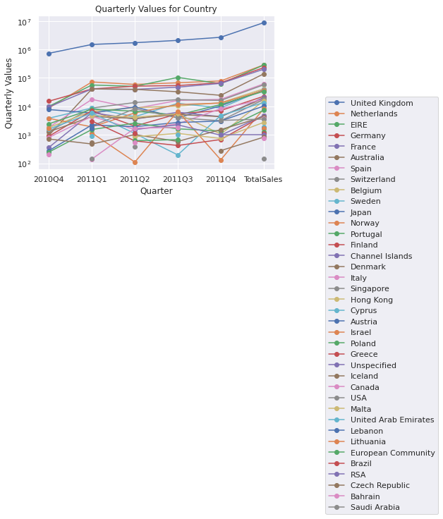

```python
# Plotting each row
for index, row in df_sales_by_country_q_pivot.iterrows():
    plt.plot(row.index, row.values, marker='o', label=index)

# Adding labels and title
plt.xlabel('Quarter')
plt.ylabel('Quarterly Values')
plt.title('Quarterly Values for Country')
plt.legend(bbox_to_anchor=(1.2, 0.5))
plt.grid(True)
plt.yscale('log')

# Display the plot
plt.show()
```

- Total Sales by top 4 Countries and year_quarter

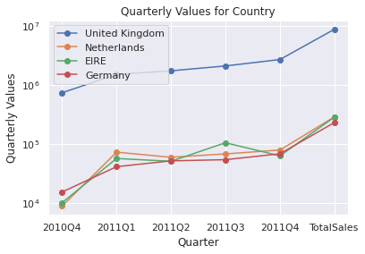

```python
# About 84% Total Sales in United Kingdom, 16% in all other countries
# Top 4 Countries: United Kingdom, Netherlands, EIRE, and Germany.
# The smallest Total Sales in Saudi Arabia

# Plotting each row
for index, row in df_sales_by_country_q_pivot.head(4).iterrows():
    plt.plot(row.index, row.values, marker='o', label=index)

# Adding labels and title
plt.xlabel('Quarter')
plt.ylabel('Quarterly Values')
plt.title('Quarterly Values for Country')
plt.legend()
plt.grid(True)
plt.yscale('log')

# Display the plot
plt.show()
```

- Total Sales by next 5 Countries and year_quarter

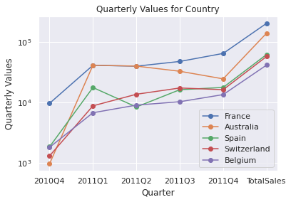

```python
# Plotting each row
for index, row in df_sales_by_country_q_pivot.iloc[4:9].iterrows():
    plt.plot(row.index, row.values, marker='o', label=index)

# Adding labels and title
plt.xlabel('Quarter')
plt.ylabel('Quarterly Values')
plt.title('Quarterly Values for Country')
plt.legend()
plt.grid(True)
plt.yscale('log')

# Display the plot
plt.show()
```

- The least Sales by last 10 countries based on the TotalSales

```python
df_sales_by_country_q_pivot.tail(10)
```

| year_quarter Country | 2010Q4 | 2011Q1 | 2011Q2 | 2011Q3 | 2011Q4 | TotalSales |
| --- | --- | --- | --- | --- | --- | --- |
| Malta | NaN | NaN | 863.16 | 1119.00 | 743.43 | 2725.59 |
| United Arab Emirates | NaN | 889.24 | NaN | 1013.04 | NaN | 1902.28 |
| Lebanon | NaN | 1693.88 | NaN | NaN | NaN | 1693.88 |
| Lithuania | 1661.06 | NaN | NaN | NaN | NaN | 1661.06 |
| European Community | NaN | NaN | 623.45 | 676.80 | NaN | 1300.25 |
| Brazil | NaN | NaN | 1143.60 | NaN | NaN | 1143.60 |
| RSA | NaN | NaN | NaN | NaN | 1002.31 | 1002.31 |
| Czech Republic | NaN | 549.26 | NaN | NaN | 277.48 | 826.74 |
| Bahrain | 205.74 | NaN | 548.40 | NaN | NaN | 754.14 |
| Saudi Arabia | NaN | 145.92 | NaN | NaN | NaN | 145.92 |

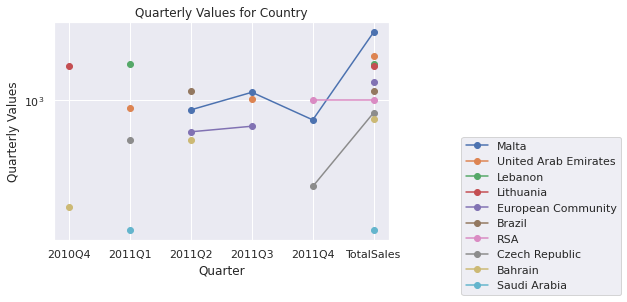

```python
# Plotting each row
for index, row in df_sales_by_country_q_pivot.tail(10).iterrows():
    plt.plot(row.index, row.values, marker='o', label=index)

# Adding labels and title
plt.xlabel('Quarter')
plt.ylabel('Quarterly Values')
plt.title('Quarterly Values for Country')
plt.legend(bbox_to_anchor=(1.2, 0.5))
plt.grid(True)
plt.yscale('log')

# Display the plot
plt.show()
```

- The busiest months in terms of sales: Sep, Oct, Nov

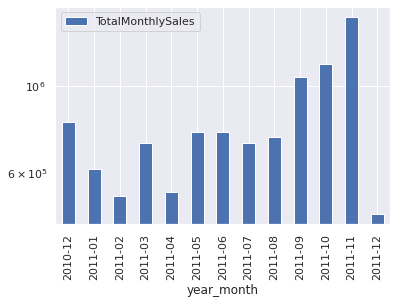

```python
ax=df_sales_by_month.plot(x='year_month', y='TotalMonthlySales', kind='bar')
ax.set_yscale('log')
plt.show()
```

- The busiest months in terms of Quantity: Sep, Oct, Nov

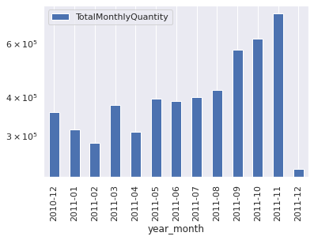

```python
ax=df_q_by_month.plot(x='year_month', y='TotalMonthlyQuantity', kind='bar')
ax.set_yscale('log')
plt.show()
```

- The busiest days of the week in terms of sales: Mon, Tue, Wed, Thr

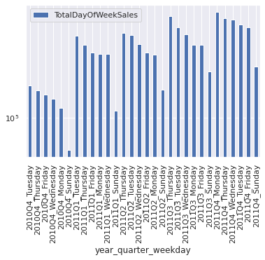

```python
# the least busy day: Sun
df_sales_by_weekdays['year_quarter_weekday']=df_sales_by_weekdays['year_quarter']+'_'+df_sales_by_weekdays['day_of_week']
ax=df_sales_by_weekdays.plot(x='year_quarter_weekday', y='TotalDayOfWeekSales', kind='bar')
ax.set_yscale('log')
plt.show()
```

- The busiest days of the week in terms of Quantity: Mon, Tue, Wed, Thr

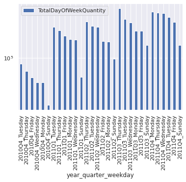

```python
# the least busy day: Sun
df_q_by_weekdays['year_quarter_weekday']=df_sales_by_weekdays['year_quarter']+'_'+df_sales_by_weekdays['day_of_week']
ax=df_q_by_weekdays.plot(x='year_quarter_weekday', y='TotalDayOfWeekQuantity', kind='bar')
ax.set_yscale('log')
plt.show()
```

- Top selling products based on the quantity sold across all countries

```python
df_by_q_top_product = df_cleaned[['Description','Quantity']].groupby(['Description']).sum()
df_by_q_top_product.rename(columns={'Quantity': 'TotalQuantity'}, inplace=True)
df_by_q_top_product.sort_values(by=['TotalQuantity'], ascending=False, inplace=True)
df_by_q_top_product.reset_index(inplace=True)

pd.set_option('max_row', None)
df_by_q_top_product
```

|  | Description | TotalQuantity |
| --- | --- | --- |
| 0 | WORLD WAR 2 GLIDERS ASSTD DESIGNS | 54951 |
| 1 | JUMBO BAG RED RETROSPOT | 48371 |
| 2 | WHITE HANGING HEART T-LIGHT HOLDER | 37872 |
| 3 | POPCORN HOLDER | 36749 |
| 4 | PACK OF 72 RETROSPOT CAKE CASES | 36396 |
| 5 | ASSORTED COLOUR BIRD ORNAMENT | 36362 |
| 6 | RABBIT NIGHT LIGHT | 30739 |
| 7 | MINI PAINT SET VINTAGE | 26633 |
| 8 | PACK OF 12 LONDON TISSUES | 26119 |
| 9 | PACK OF 60 PINK PAISLEY CAKE CASES | 24820 |
| 10 | VICTORIAN GLASS HANGING T-LIGHT | 24275 |
| 11 | ASSORTED COLOURS SILK FAN | 23826 |
| 12 | BROCADE RING PURSE | 23020 |
| 13 | RED HARMONICA IN BOX | 21903 |
| 14 | JUMBO BAG PINK POLKADOT | 21448 |
| 15 | SMALL POPCORN HOLDER | 20149 |
| 16 | PAPER CHAIN KIT 50'S CHRISTMAS | 19329 |
| 17 | LUNCH BAG RED RETROSPOT | 19232 |
| 18 | PARTY BUNTING | 18283 |
| 19 | 60 TEATIME FAIRY CAKE CASES | 18189 |
| 20 | CHARLOTTE BAG SUKI DESIGN | 18124 |
| 21 | HEART OF WICKER SMALL | 17963 |
| 22 | RED RETROSPOT CHARLOTTE BAG | 17761 |
| 23 | JUMBO BAG STRAWBERRY | 17283 |
| 24 | COLOUR GLASS T-LIGHT HOLDER HANGING | 16401 |
| 25 | JAM MAKING SET PRINTED | 16396 |
| 26 | GROW A FLYTRAP OR SUNFLOWER IN TIN | 16244 |
| 27 | 60 CAKE CASES VINTAGE CHRISTMAS | 16032 |
| 28 | PACK OF 72 SKULL CAKE CASES | 15169 |
| 29 | PLACE SETTING WHITE HEART | 15126 |

[output cut: 3994 more lines]

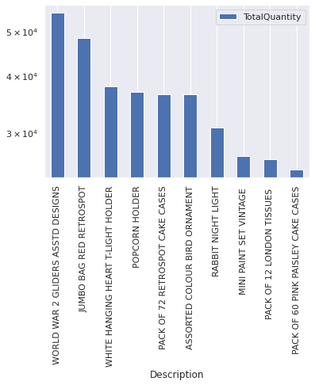

```python
# top 10 products
ax=df_by_q_top_product.head(10).plot(x='Description', y='TotalQuantity', kind='bar')
ax.set_yscale('log')
plt.show()
```

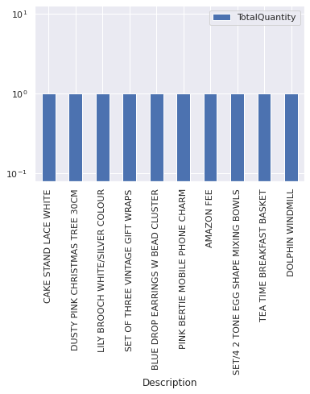

```python
# least 10 products (Amazon Fee??)
ax=df_by_q_top_product.tail(10).plot(x='Description', y='TotalQuantity', kind='bar')
ax.set_yscale('log')
plt.show()
```

- Top customers based on the Quantity purchased are from ['United Kingdom', 'EIRE', 'Netherlands', 'Australia']

```python
df_by_custid_q = save_df_cust[['CustomerID','Quantity']].groupby(['CustomerID']).sum()
df_by_custid_q.rename(columns={'Quantity': 'TotalQuantity'}, inplace=True)
df_by_custid_q.sort_values(by=['TotalQuantity'], ascending=False, inplace=True)
df_by_custid_q.reset_index(inplace=True)

#top 10 customers based on quantity purchased
df_by_custid_q.head(10)
```

|  | CustomerID | TotalQuantity |
| --- | --- | --- |
| 0 | 14646.0 | 197491 |
| 1 | 16446.0 | 80997 |
| 2 | 14911.0 | 80490 |
| 3 | 12415.0 | 77670 |
| 4 | 12346.0 | 74215 |
| 5 | 17450.0 | 69973 |
| 6 | 17511.0 | 64549 |
| 7 | 18102.0 | 64124 |
| 8 | 13694.0 | 63312 |
| 9 | 14298.0 | 58343 |

```python
# Products Sample list purchased by top 10 customers
top_cust_df['Description'].unique().tolist()[0:20]
```

```
['CHRISTMAS LIGHTS 10 REINDEER',
 'JAM MAKING SET WITH JARS',
 'JAM MAKING SET PRINTED',
 'JAM JAR WITH PINK LID',
 'JAM JAR WITH GREEN LID',
 'ROSE COTTAGE KEEPSAKE BOX ',
 'HANGING HEART ZINC T-LIGHT HOLDER',
 'PAPER CHAIN KIT VINTAGE CHRISTMAS',
 'DISCO BALL CHRISTMAS DECORATION',
 'WHITE HANGING HEART T-LIGHT HOLDER',
 'SMALL POPCORN HOLDER',
 'LARGE POPCORN HOLDER ',
 'RETROSPOT LARGE MILK JUG',
 'SET/20 RED RETROSPOT PAPER NAPKINS ',
 'SET/6 RED SPOTTY PAPER PLATES',
 'SET/6 RED SPOTTY PAPER CUPS',
 'POLKADOT RAIN HAT ',
 'DELUXE SEWING KIT ',
 'RETROSPOT HEART HOT WATER BOTTLE',
 'KNITTED UNION FLAG HOT WATER BOTTLE']
```

## Discussion

In this project, we analyzed transactional data from an online retail store spanning from 2010 to 2011. The dataset, named Online Retail.xlsx, contains information on customer purchases from 38 countries, including product details, quantities, prices, and timestamps. Our goal was to explore and analyze this data to gain insights into sales trends, customer behavior, and popular products, ultimately aiding in making key business decisions. This project aims to provide actionable insights that can drive strategic business decisions and enhance the store's overall performance in the competitive online retail market.

We performed data cleaning to prepare the data for analysis, ensuring it met quality criteria such as validity, uniformity, accuracy, consistency, and completeness. Data cleansing involved removing unwanted, duplicate, and incorrect data from the dataset, thus helping us develop accurate insights. During this process, we identified several anomalies:

- 5268 duplicate rows
- 1454 rows with missing descriptions
- approximately 25% of all rows with missing customer IDs (unique identifiers for customers)
- 9727 rows with either negative quantities or unit prices
- 581 rows with zero sales (Quantity * UnitPrice) due to a unit price of 0
- 442 rows without specified countries where transactions occurred

These anomalies indicate data management issues, such as the lack of methods to detect redundant observations and identify missing values for crucial fields like descriptions or customer IDs. Negative quantities, negative or zero unit prices are incorrect and impact accurate insights into sales.

We also identified nine unit price outliers with descriptions like fee, postages, manual, and adjust bad debt. Clearer descriptions would provide better insights into these outliers. Additionally, there were three quantity outliers (occurring in the United Kingdom), one of which had a unit price of 0. We should pay attention to these outliers (MEDIUM CERAMIC TOP STORAGE JAR, ASSTD DESIGN 3D PAPER STICKERS, and PAPER CRAFT, LITTLE BIRDIE) when forecasting future sales in the United Kingdom, as they seem to be the most sellable items.

Sales are calculated as Quantity * UnitPrice, with DOTCOM POSTAGE being the top sale. The most frequently bought products are WHITE HANGING HEART T-LIGHT HOLDER and JUMBO BAG RED RETROSPOT, and the most frequent quantities sold are 1 and 2. The best-selling products based on quantity sold are WORLD WAR 2 GLIDERS ASSTD DESIGNS, JUMBO BAG RED RETROSPOT, and WHITE HANGING HEART T-LIGHT HOLDER. TO MATCH ALL CUSHIONS is the product with the smallest sale.

The busiest months in terms of sales or quantity sold are September, October, and November. The busiest days of the week are Monday, Tuesday, Wednesday, and Thursday. It seems strange that Sunday is the least busy day, so further research is needed to understand this. The top customers based on quantity purchased are from the United Kingdom, EIRE, the Netherlands, and Australia.

## Conclusion

- Addressing data management issues identified during the data cleansing step would be highly beneficial. If the dataset is to be maintained in Excel, consider adding macros to detect redundant observations and identify missing values in crucial fields like descriptions or customer IDs. Macros can also correct negative quantities, negative or zero unit prices, or unspecified countries.
- Next, consider repeating the same analysis performed in this project for each of the 38 countries to obtain more detailed information about sales trends, customer behavior, and popular products. This will help tailor strategic business decisions and enhance the store's overall performance.
- Revising some of the descriptions to accurately capture the nature of the products in question is also recommended. Clearer descriptions would provide better insights into items like fees, postages, manuals, and adjustments for bad debt.
- Further research should be conducted to identify the best products for countries with the smallest sales, such as Malta, the United Arab Emirates, or Saudi Arabia. Additionally, investigate why Sunday is the least busy day in terms of sales.
- When forecasting future sales in the United Kingdom, be mindful of quantity outliers, as they appear to be the most sellable items.